# Non Linear Models

# Polynomial Regression

Use poly() command within the lm function.

poly(age,4) returns a matrix whose columns are a basis of orthogonal polynomials (each column is a linear combination of the variables age, age^2, age^3 and age^4).

We can use poly() to obtain age, age^2, age^3 and age^4 directly by using the raw=TRUE argument.

Even though it affects the coefficient estimates, it does not affect the fitted values.

```r
library(ISLR)

fit=lm(wage???poly(age,4) , data=Wage)
coef(summary(fit))

fit2=lm(wage???poly(age ,4,raw=T),data=Wage)
coef(summary(fit2))

agelims=range(age) #a vector of two elements (min and max)
age.grid=seq(from=agelims[1], to=agelims[2]) #by=1 by default
preds=predict(fit, newdata=list(age=age.grid), se=TRUE)
preds2=predict(fit2, newdata=list(age=age.grid), se=TRUE)
max(abs(preds$fit-preds2$fit)) #the maximum difference between the fitted values of fit and fit2
```

[output not shown]

There are several other equivalent ways of fitting polynomial regression model.

We can use the wrapper function I() to protect terms since the ^ symbol has a special meaning in formulas.

cbind() function does the same more compactly by building a matrix from a collection of vectors.

```r
fit2a=lm(wage???age+I(age^2)+I(age^3)+I(age^4),data=Wage)
coef(summary(fit2a))

fit2b=lm(wage???cbind(age, age^2, age^3, age ^4),data=Wage)
coef(summary(fit2b))
```

[output not shown]

We use our model to predict wages using age and plot the data (dark grey) together with the fit (blue line with confidence interval).

```r
preds=predict(fit, newdata=list(age=age.grid), se=TRUE)
se.bands=cbind(preds$fit+2*preds$se.fit, preds$fit-2*preds$se.fit) #create the confidence bands

par(mfrow=c(1,2), mar=c(4.5,4.5,1,1), oma=c(0,0,4,0)) #mar and oma to control the margins of the plot
plot(age, wage, xlim=agelims, cex =.5, col="darkgrey") #scatterplot at the background
title("Degree-4 Polynomial",outer=T)
lines(age.grid, preds$fit, lwd=2, col="blue")
matlines(age.grid, se.bands, lwd=1, col="blue", lty=3)
```

[output not shown]

We need to decide on the degree of the polynomial to use. One way to do this is by using hypothesis tests.

We fit models ranging from linear to a degree-5 polynomial and seek to determine the simplest model which is sufficient to explain the relationship.

We use the anova() function, which performs a F-test in order to test the null hypothesis that a model M1 is sufficient to explain the data against the alternative hypothesis that a more complex model M2 is required.

In order to use the anova() function, M1 and M2 must be nested models: the predictors in M1 must be a subset of the predictors in M2.

The p-value comparing the linear model M1 to the quadratic model M2 is essentially zero (2.2e-16), indicating that a linear fit is not sufficient.

The p-value comparing the cubic and degree-4 polynomials is approximately 5% while the degree-5 polynomial seems unnecessary because its p-value is 0.37.

Hence, either a cubic or a degree-4 polynomial appear to provide a reasonable fit to the data.

```r
fit.1=lm(wage~age ,data=Wage)
fit.2=lm(wage~poly(age ,2),data=Wage)
fit.3=lm(wage~poly(age ,3),data=Wage)
fit.4=lm(wage~poly(age ,4),data=Wage)
fit.5=lm(wage~poly(age ,5),data=Wage)
anova(fit.1, fit.2, fit.3, fit.4, fit.5)
```

```
Analysis of Variance Table

Model 1: wage ~ age
Model 2: wage ~ poly(age, 2)
Model 3: wage ~ poly(age, 3)
Model 4: wage ~ poly(age, 4)
Model 5: wage ~ poly(age, 5)
  Res.Df     RSS Df Sum of Sq        F    Pr(>F)
1   2998 5022216
2   2997 4793430  1    228786 143.5931 < 2.2e-16 ***
3   2996 4777674  1     15756   9.8888  0.001679 **
4   2995 4771604  1      6070   3.8098  0.051046 .
5   2994 4770322  1      1283   0.8050  0.369682
---
Signif. codes:  0 *** 0.001 ** 0.01 * 0.05 . 0.1   1
```

We can also use anova() when we have other terms in the model.

```r
fit.1=lm(wage~education+age, data=Wage)
fit.2=lm(wage~education+poly(age,2), data=Wage)
fit.3=lm(wage~education+poly(age,3), data=Wage)
anova(fit.1, fit.2, fit.3)
```

```
Analysis of Variance Table

Model 1: wage ~ education + age
Model 2: wage ~ education + poly(age, 2)
Model 3: wage ~ education + poly(age, 3)
  Res.Df     RSS Df Sum of Sq        F Pr(>F)
1   2994 3867992
2   2993 3725395  1    142597 114.6969 <2e-16 ***
3   2992 3719809  1      5587   4.4936 0.0341 *
---
Signif. codes:  0 *** 0.001 ** 0.01 * 0.05 . 0.1   1
```

## Logistic Regression

We want to predict whether an individual earns more than $250,000 per year.

First we create the appropriate response vector. We use the wrapper I(wage>250) to create a binary response variable. The expression “wage>250” evaluates to a logical variable containing TRUEs and FALSEs, which glm() coerces to binary by setting the TRUEs to 1 and the FALSEs to 0.

Then we apply the glm() function using family=“binomial” in order to fit a polynomial logistic regression model.

We use our model to predict probability using age. The default prediction type for a glm() model is type=“link”. This means we get predictions and standard erros for the logit(log odds): log(p/1-p)=X??

In order to obtain confidence intervals for probability, we use the transformation p=exp(X??)/(1+exp(X??)).

Note that we could have directly computed the probabilities by selecting type=“response” option in the predict() function. However, the corresponding confidence intervals would not have been sensible because we would end up with negative probabilities!

```r
fit=glm(I(wage>250)~poly(age,4), data=Wage, family=binomial)
preds=predict(fit, newdata=list(age=age.grid), se=T)
pfit=exp(preds$fit)/(1+exp(preds$fit))
se.bands.logit=cbind(preds$fit+2*preds$se.fit, preds$fit-2*preds$se.fit)
se.bands=exp(se.bands.logit)/(1+exp(se.bands.logit))
```

We plot the data together with the fit.

We have drawn the age values corresponding to the observations with wage values above 250 as gray marks on the top of the plot, and those with wage values below 250 are shown as gray marks on the bottom of the plot.

We used the jitter() function to jitter the age values a bit so that observations with the same age value do not cover each other up.

```r
plot(age, I(wage>250), xlim=agelims, type="n", ylim=c(0,.2))
points(jitter(age), I((wage>250)/5), cex=.5, pch ="|", col="darkgrey")
```

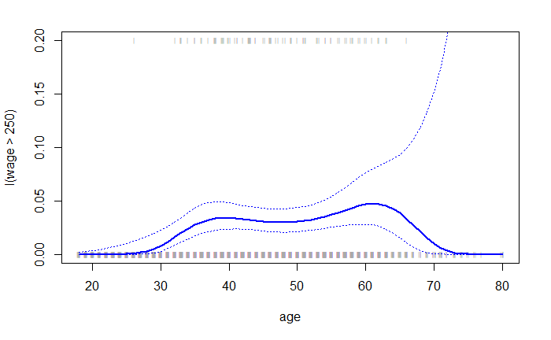

```r
lines(age.grid, pfit,lwd=2, col="blue")
matlines(age.grid, se.bands, lwd=1, col="blue", lty=3)
```

# Step function

Use the cut() function to fit a step function

The function cut() assigns each observation to one of the 4 intervals, the lm() function then creates a set of dummy variables for use in the regression.

```r
table(cut(age,4)) #4 intervals so 3 cutpoints
fit=lm(wage???cut(age,4), data=Wage)
coef(summary(fit))
```

[output not shown]

# Splines

Regression splines can be fit by constructing an appropriate matrix of basis functions.

The bs() function in the the splines library generates the entire matrix of basis functions for splines with specified set of knots.

We prespecify the knots at ages 25, 40, and 60. This produces a spline with six basis functions. Also, recall that a cubic spline with three knots has seven degrees of freedom.

We could also use the df option to produce a spline with knots at uniform quantiles of the data.

By default, cubic splines are produced. However, the function bs() also has a degree argument, so we can fit splines of any degree, rather than the default degree of 3.

```r
library(splines)
dim(bs(age, knots=c(25,40,60))) #prespecified knots
```

```
[1] 3000    6
```

```r
dim(bs(age, df=6)) #prespecified degree of freedom produces knots at uniform quantiles
```

```
[1] 3000    6
```

```r
attr(bs(age, df=6), "knots")
```

```
  25%   50%   75%
33.75 42.00 51.00
```

```r
fit=lm(wage~bs(age, knots=c(25,40,60)), data=Wage)
pred=predict(fit, newdata=list(age=age.grid), se=T)
plot(age, wage, col="gray")
lines(age.grid, pred$fit ,lwd=2)
```

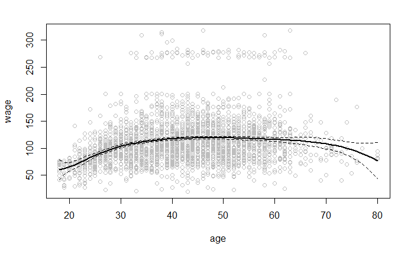

```r
lines(age.grid, pred$fit+2*pred$se, lty="dashed")
lines(age.grid, pred$fit-2*pred$se, lty="dashed")
```

# Natural Spline

We can use the ns() function to fit a natural spline with four degrees of freedom.

As with the bs() function, we could instead specify the knots directly using the knots option.

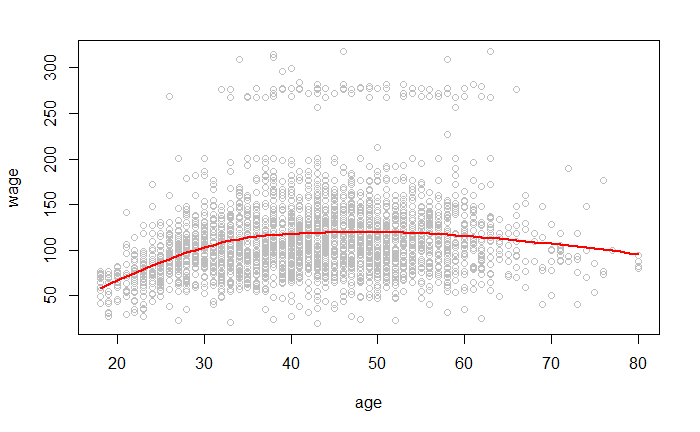

```r
fit2=lm(wage~ns(age, df=4), data=Wage)
pred2=predict(fit2, newdata=list(age=age.grid), se=T)
plot(age, wage, col="gray")
lines(age.grid, pred2$fit, col="red", lwd=2)
```

# Smoothing Spline

We use the smooth.spline() function to fit a smoothing spline.

In the first call to smooth.spline(), we specified df=16. The function then determines which value of ?? leads to 16 degrees of freedom.

In the second call to smooth.spline(), we select the smoothness level by cross-validation. This results in a value of ?? that yields 6.8 degrees of freedom.

```r
fit=smooth.spline(age, wage, df=16)
fit2=smooth.spline(age, wage, cv=TRUE)
```

```
cross-validation with non-unique 'x' values seems doubtful
```

```r
fit2$df
```

```
[1] 6.794596
```

```r
plot(age, wage, xlim=agelims, cex =.5, col="darkgrey")
title("Smoothing Spline")
```

```r
lines(fit, col="red", lwd =2)
lines(fit2, col="blue", lwd=2)
```

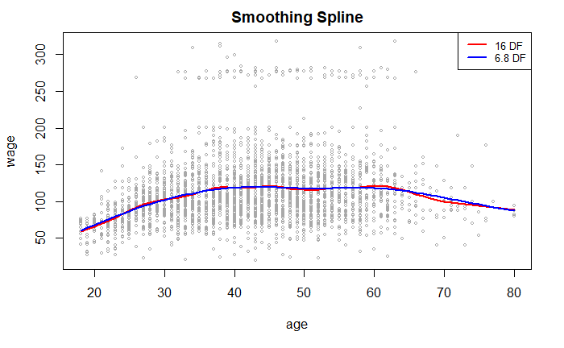

```r
legend("topright", legend=c("16 DF" ,"6.8 DF"), col=c("red","blue"), lty=1, lwd=2, cex =.8)
```

# Local Regression

We use the loess() function to perform local regression.

We perform local linear regression using spans of 0.2 and 0.5: that is, each neighborhood consists of 20 % or 50 % of the observations. The larger the span, the smoother the fit.

The locfit library can also be used for fitting local regression models.

```r
fit=loess(wage~age, span=.2, data=Wage)
fit2=loess(wage~age, span=.5, data=Wage)
plot(age, wage, xlim=agelims, cex =.5, col="darkgrey")
title("Local Regression")
```

```r
lines(age.grid, predict(fit,data.frame(age=age.grid)), col="red", lwd=2)
lines(age.grid, predict(fit2,data.frame(age=age.grid)), col="blue", lwd=2)
```

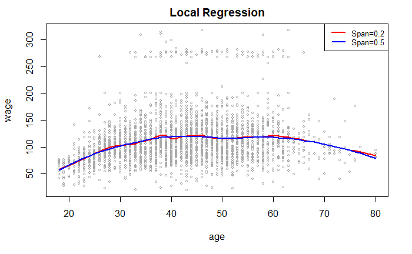

```r
legend("topright", legend=c("Span=0.2","Span=0.5"), col=c("red","blue"), lty=1, lwd=2, cex=.8)
```

# GAMs

We first fit a GAM to predict wage using natural spline functions of year and age, treating education as a qualitative predictor. We then fit the model using smoothing splines rather than natural splines.

We use the gam() function in gam library.The s() function, which is part of the gam library, is used to indicate that we would like to use a smoothing spline.

```r
library(gam)
gam1=gam(wage???ns(year,4)+ns(age,5)+education, data=Wage) #4 df for year and 5 df for age
gam2=gam(wage???s(year,4)+s(age,5)+education, data=Wage)

par(mfrow=c(1,3))
plot(gam2, se=TRUE, col="blue") #setting se=TRUE will produce the confidence bands on the graph
plot(gam1, se=TRUE, col="red")
```

[output not shown]

In these plots, the function of year looks rather linear. We can perform a series of ANOVA tests in order to determine which of these three models is best: a GAM that excludes year (M1), a GAM that uses a linear function of year (M2), or a GAM that uses a smoothing spline function of year (M3).

However, there is no evidence that a non-linear function of year is needed (p-value = 0.349). Therefore, based on the results of this ANOVA, M2 is preferred.

```r
gam.m1=gam(wage???s(age,5)+education, data=Wage)
gam.m2=gam(wage???year+s(age,5)+education, data=Wage)
gam.m3=gam(wage???s(year,4)+s(age,5)+education, data=Wage)
anova(gam.m1, gam.m2, gam.m3, test="F")
```

[output not shown]

The summary() function produces a summary of the gam fit.

For Anova for Nonparametric Effects, the p-values for year and age correspond to a null hypothesis of a linear relationship versus the alternative of a non-linear relationship.

The large p-value for year reinforces our conclusion from the ANOVA test that a linear function is adequate for this term.

However, there is very clear evidence that a non-linear term is required for age.

```r
summary(gam.m3)
```

[output not shown]

We can make predictions from gam objects using the predict() method (just like for lm objects).

```r
preds=predict(gam.m2, newdata=Wage)
```

We can use local regression fits as building blocks in a GAM, using the lo() function.

We can also use the lo() function to create interactions before calling the gam() function.

We can plot the resulting two-dimensional surface by installing the akima package.

```r
gam.lo=gam(wage???s(year,df=4)+lo(age,span =0.7)+education, data=Wage) #local regression for the age term, with a span of 0.7
plot(gam.lo, se=TRUE, col="green")

gam.lo.i=gam(wage???lo(year,age,span=0.5)+education, data=Wage) #an interaction term between year and age, fit by a local regression surface
library(akima)
plot(gam.lo.i)
```

[output not shown]

## Logsitic Regression

We use the I() function in constructing the binary response variable, and set family=binomial.

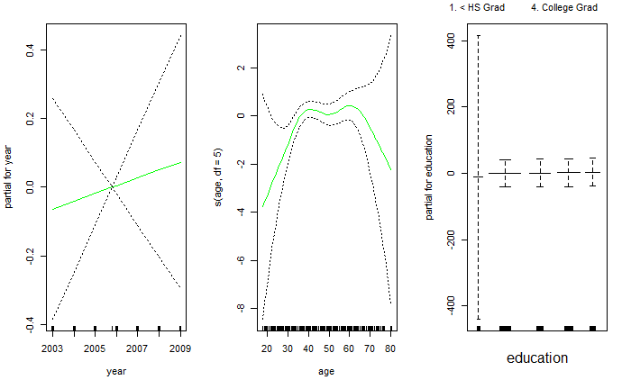

```r
gam.lr=gam(I(wage>250)~year+s(age,df=5)+education, family=binomial, data=Wage)
par(mfrow=c(1,3))
plot(gam.lr, se=T, col="green")
```

```r
table(education, I(wage>250)) #education and I(wage>250) are objects which can be interpreted as factors so R build a table of the counts at each combination of factor levels
```

```
education            FALSE TRUE
  1. < HS Grad         268    0
  2. HS Grad           966    5
  3. Some College      643    7
  4. College Grad      663   22
  5. Advanced Degree   381   45
```

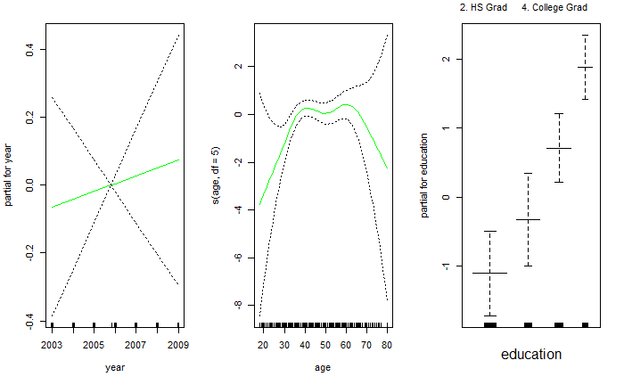

```r
gam.lr.s=gam(I(wage>250)~year+s(age,df=5)+education, family=binomial, data=Wage, subset=(education != "1. < HS Grad"))
par(mfrow=c(1,3))
plot(gam.lr.s, se=T, col="green")
```